# Mortalidad por bajas de oxígeno por Barrio

Gabriela Salas

2022-06-29

**Descripción del problema:** La mortalidad en salmones de cultivo es uno de los problemas que enfrenta la industria salmonera desde sus inicios, en la actualidad, los cambios en el clima ha afectado particularmente a aesta industria, en cuanto a variaciones en la temperatura del agua, horas luz, salinidad y variaciones de oxígeno disuelto entre otros, en este estudio intentaremos dilucidar si existen una tendencia según la unbicación de las unidades de cultivo dentro de la X Región y la mortalidad por bajas de oxígeno

**Descripción de las Variables de estudios:** Las variables que se usarán son los barrios donde estan ubicados los centros dentro de la X Región (Agrupacion de Centros), Mortalidad total (Total_Mortalidad) y Mortalidad por bajas de Oxigeno (Mortalidad_O2)

**Numero de observaciones:** 44

** Análisis Exploratorio de Datos**

```r
Mortalidad_Salmones <- read_excel("R_2.xlsx", sheet=1,na="NA")
head(Mortalidad_Salmones)
```

```
## # A tibble: 6 × 45
##   Especie Generacion Barrio Centro     Alimento Oxigeno Siembra Mortalidad_Total
##   <chr>        <dbl> <chr>  <chr>         <dbl>   <dbl>   <dbl>            <dbl>
## 1 Coho          2017 16     2017-Reñi…  3142200   10.2  1000000            34201
## 2 Coho          2017 17A    2017-Tamb…  5089975    7.87 1500002            59991
## 3 Coho          2017 17B    2017-Llan…  6465975   10.7  1500000            38327
## 4 Coho          2018 17B    2018-Llan…  7028236   11.6  1500000            24908
## 5 Coho          2018 7      2018-Tubi…  4878629    8.02  988500            19047
## 6 Coho          2019 17A    2019-Tamb…  5828450    7.53 1500000            47867
## # … with 37 more variables: Amebiasis <dbl>, Mort_O2 <dbl>, BKD <dbl>,
## #   Bloat <dbl>, Bloom_Algas <dbl>, Daño_Mecánico <dbl>, Deformes <dbl>,
## #   Desadaptados <dbl>, Eliminacion_productiva <dbl>,
## #   Eliminacion_sanitaria <dbl>, `Enf. Proliferativa branquial (PGD)` <dbl>,
## #   Exophiala <dbl>, Flavobacteriosis <dbl>, `Golpe craneal` <dbl>,
## #   Hongos <dbl>, Ictericia <dbl>, `Impactación gástrica` <dbl>, Lobo <dbl>,
## #   Maduro <dbl>, Manejo <dbl>, Muestras <dbl>, Nefrocalcinosis <dbl>, …
```

```r
##Ordenar R_2 creando un objeto tidy_Mortalidad con las variables de interés:
tidy_Mortalidad <- select(Mortalidad_Salmones,Centro,Barrio,Oxigeno,Siembra,Mortalidad_Total,Mort_O2)
head(tidy_Mortalidad)
```

```
## # A tibble: 6 × 6
##   Centro          Barrio Oxigeno Siembra Mortalidad_Total Mort_O2
##   <chr>           <chr>    <dbl>   <dbl>            <dbl>   <dbl>
## 1 2017-Reñihue Gl 16       10.2  1000000            34201       0
## 2 2017-Tambor     17A       7.87 1500002            59991      42
## 3 2017-Llancahue  17B      10.7  1500000            38327       0
## 4 2018-Llancahue  17B      11.6  1500000            24908       0
## 5 2018-Tubildad   7         8.02  988500            19047     380
## 6 2019-Tambor     17A       7.53 1500000            47867     234
```

```r
#Transformar a Factor
tidy_Mortalidad$Centro <- as.factor(tidy_Mortalidad$Centro)
tidy_Mortalidad$Barrio <- as.factor(tidy_Mortalidad$Barrio)

summary(tidy_Mortalidad)
```

```
##              Centro   Barrio      Oxigeno          Siembra
##  2017-Cholgo    : 1   10A: 2   Min.   : 6.140   Min.   : 696340
##  2017-Linguar   : 1   16 : 8   1st Qu.: 7.147   1st Qu.: 974402
##  2017-Llancahue : 1   17A: 9   Median : 7.735   Median :1024484
##  2017-Morrolobos: 1   17B:14   Mean   : 7.833   Mean   :1109927
##  2017-Reñihue Gl: 1   7  : 7   3rd Qu.: 8.225   3rd Qu.:1165839
##  2017-Tambor    : 1   8  : 2   Max.   :11.650   Max.   :1900000
##  (Other)        :38   9B : 2
##  Mortalidad_Total    Mort_O2
##  Min.   :  6624   Min.   :    0.00
##  1st Qu.: 32201   1st Qu.:   67.25
##  Median :101716   Median : 3656.50
##  Mean   :116640   Mean   :11028.39
##  3rd Qu.:174962   3rd Qu.:14896.00
##  Max.   :428005   Max.   :55797.00
##
```

Se puede observar que los datos no se encuentran balanceados ya que en los barrios 10A, 8 y 9B sólo hay 2 muestras, mientras que en barrios como el 17B y 17A hay 14 y 9 respectivamente.

```r
str(tidy_Mortalidad)
```

```
## tibble [44 × 6] (S3: tbl_df/tbl/data.frame)
##  $ Centro          : Factor w/ 44 levels "2017-Cholgo",..: 5 6 3 12 15 22 21 29 30 32 ...
##  $ Barrio          : Factor w/ 7 levels "10A","16","17A",..: 2 3 4 4 5 3 4 4 4 5 ...
##  $ Oxigeno         : num [1:44] 10.17 7.87 10.7 11.65 8.02 ...
##  $ Siembra         : num [1:44] 1000000 1500002 1500000 1500000 988500 ...
##  $ Mortalidad_Total: num [1:44] 34201 59991 38327 24908 19047 ...
##  $ Mort_O2         : num [1:44] 0 42 0 0 380 ...
```

```r
DT::datatable(tidy_Mortalidad,caption="Tabla 1. Resumen Mortalidad por Oxigeno por centro y Barrio")
```

|  | Centro | Barrio | Oxigeno | Siembra | Mortalidad_Total | Mort_O2 |
| --- | --- | --- | --- | --- | --- | --- |
| 1 | 2017-Reñihue Gl | 16 | 10.17 | 1000000 | 34201 | 0 |
| 2 | 2017-Tambor | 17A | 7.87 | 1500002 | 59991 | 42 |
| 3 | 2017-Llancahue | 17B | 10.7 | 1500000 | 38327 | 0 |
| 4 | 2018-Llancahue | 17B | 11.65 | 1500000 | 24908 | 0 |
| 5 | 2018-Tubildad | 7 | 8.02 | 988500 | 19047 | 380 |
| 6 | 2019-Tambor | 17A | 7.53 | 1500000 | 47867 | 234 |
| 7 | 2019-Pichanco | 17B | 7.14 | 1000000 | 6624 | 71 |
| 8 | 2020-Pelada | 17B | 6.82 | 920000 | 19637 | 223 |
| 9 | 2020-Pichanco | 17B | 6.66 | 920000 | 20396 | 4663 |
| 10 | 2020-Tubildad | 7 | 6.16 | 920000 | 19575 | 1985 |

[output cut: 34 more lines]

```r
pander(summary(tidy_Mortalidad,caption="Tabla 2. Resumen"))
```

Table continues below

| Centro | Barrio | Oxigeno | Siembra |
| --- | --- | --- | --- |
| 2017-Cholgo : 1 | 10A: 2 | Min. : 6.140 | Min. : 696340 |
| 2017-Linguar : 1 | 16 : 8 | 1st Qu.: 7.147 | 1st Qu.: 974402 |
| 2017-Llancahue : 1 | 17A: 9 | Median : 7.735 | Median :1024484 |
| 2017-Morrolobos: 1 | 17B:14 | Mean : 7.833 | Mean :1109927 |
| 2017-Reñihue Gl: 1 | 7 : 7 | 3rd Qu.: 8.225 | 3rd Qu.:1165839 |
| 2017-Tambor : 1 | 8 : 2 | Max. :11.650 | Max. :1900000 |
| (Other) :38 | 9B : 2 | NA | NA |

| Mortalidad_Total | Mort_O2 |
| --- | --- |
| Min. : 6624 | Min. : 0.00 |
| 1st Qu.: 32201 | 1st Qu.: 67.25 |
| Median :101716 | Median : 3656.50 |
| Mean :116640 | Mean :11028.39 |
| 3rd Qu.:174962 | 3rd Qu.:14896.00 |
| Max. :428005 | Max. :55797.00 |
| NA | NA |

```r
Datos_mortaldiad<-tidy_Mortalidad %>% group_by(Barrio)%>% summarize (n=n(),sum(Mort_O2), mean(Mort_O2), median(Mort_O2), max(Mort_O2), Variance= var(Mort_O2) )


knitr::kable(Datos_mortaldiad,caption ="Estimadores puntuales de media y varianza")
```

Estimadores puntuales de media y varianza

| Barrio | n | sum(Mort_O2) | mean(Mort_O2) | median(Mort_O2) | max(Mort_O2) | Variance |
| --- | --- | --- | --- | --- | --- | --- |
| 10A | 2 | 11765 | 5882.500 | 5882.5 | 11765 | 69207612 |
| 16 | 8 | 6872 | 859.000 | 52.0 | 5056 | 3169801 |
| 17A | 9 | 178022 | 19780.222 | 25256.0 | 37209 | 268998519 |
| 17B | 14 | 173330 | 12380.714 | 6558.0 | 55797 | 270050518 |
| 7 | 7 | 18423 | 2631.857 | 1202.0 | 11999 | 18012292 |
| 8 | 2 | 66925 | 33462.500 | 33462.5 | 43167 | 188354640 |
| 9B | 2 | 29912 | 14956.000 | 14956.0 | 15076 | 28800 |

** GRaficos Histogramas & Boxplot**

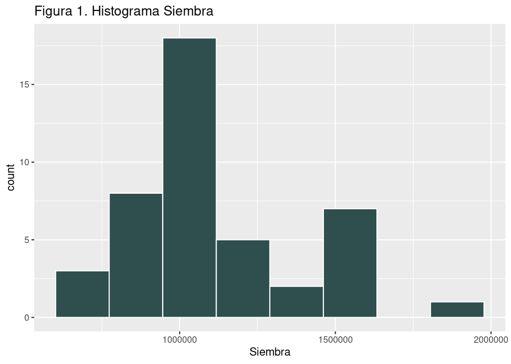

```r
hist_Siembra <- ggplot(tidy_Mortalidad,aes(Siembra))+
  geom_histogram(color="White",fill="#2F4F4F",bins=8)+
  labs(title = "Figura 1. Histograma Siembra")
hist_Siembra
```

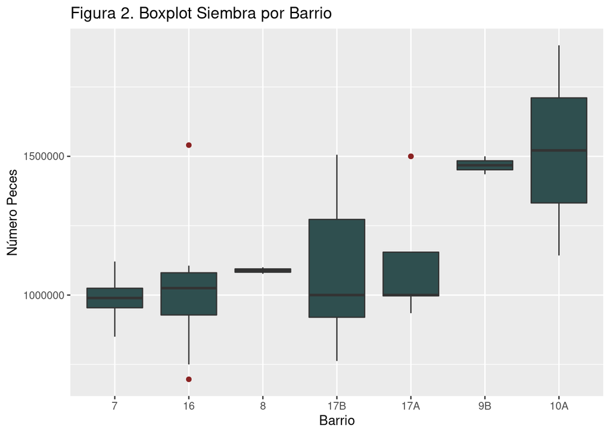

```r
blot_Siembra <- ggplot(tidy_Mortalidad,aes(y=Siembra,x=reorder(Barrio, Siembra)))+
  geom_boxplot(fill="#2F4F4F",outlier.colour = "#8B2323")+
  labs(title="Figura 2. Boxplot Siembra por Barrio",y="Número Peces",x="Barrio")
blot_Siembra
```

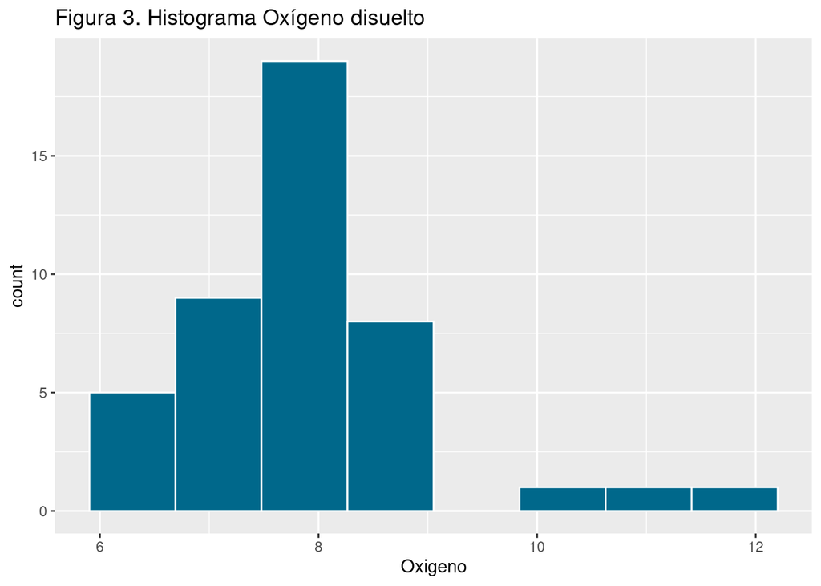

```r
hist_O2 <- ggplot(tidy_Mortalidad,aes(Oxigeno))+
  geom_histogram(color="White",fill="#00688B",bins=8)+
  labs(title = "Figura 3. Histograma Oxígeno disuelto")
hist_O2
```

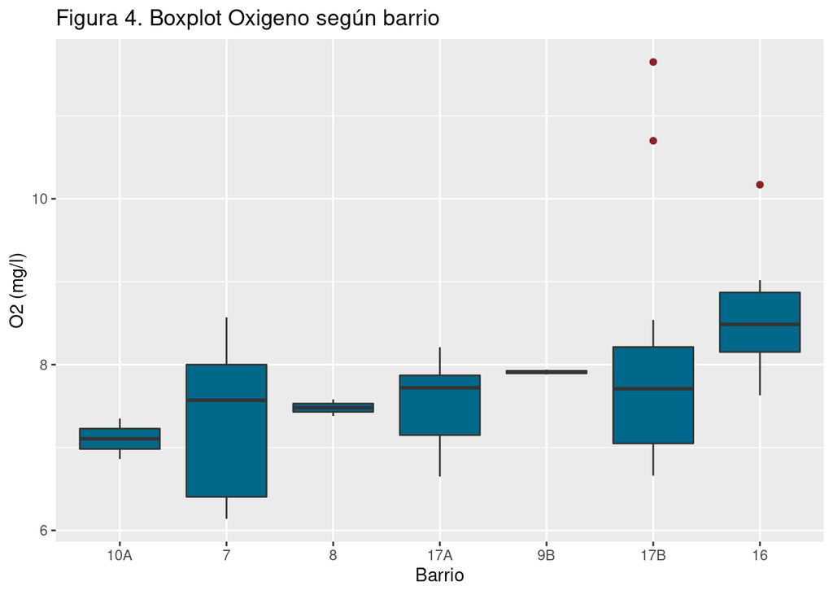

```r
blot_O2 <- ggplot(tidy_Mortalidad,aes(y=Oxigeno,x=reorder(Barrio, Oxigeno)))+
  geom_boxplot(fill="#00688B",outlier.colour = "#8B2323")+
  labs(title="Figura 4. Boxplot Oxigeno según barrio",y="O2 (mg/l)",x="Barrio")
blot_O2
```

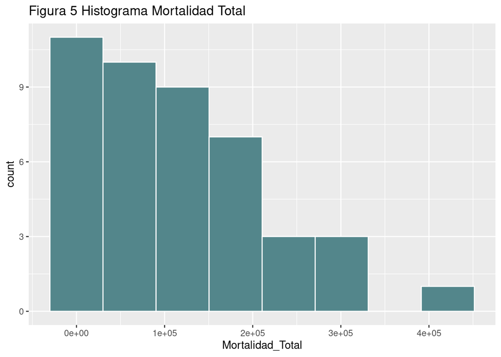

```r
hist_Mortalidad_Total <- ggplot(tidy_Mortalidad,aes(Mortalidad_Total))+
  geom_histogram(color="White", fill="#53868B",bins=8)+
  labs(title = "Figura 5 Histograma Mortalidad Total")
hist_Mortalidad_Total
```

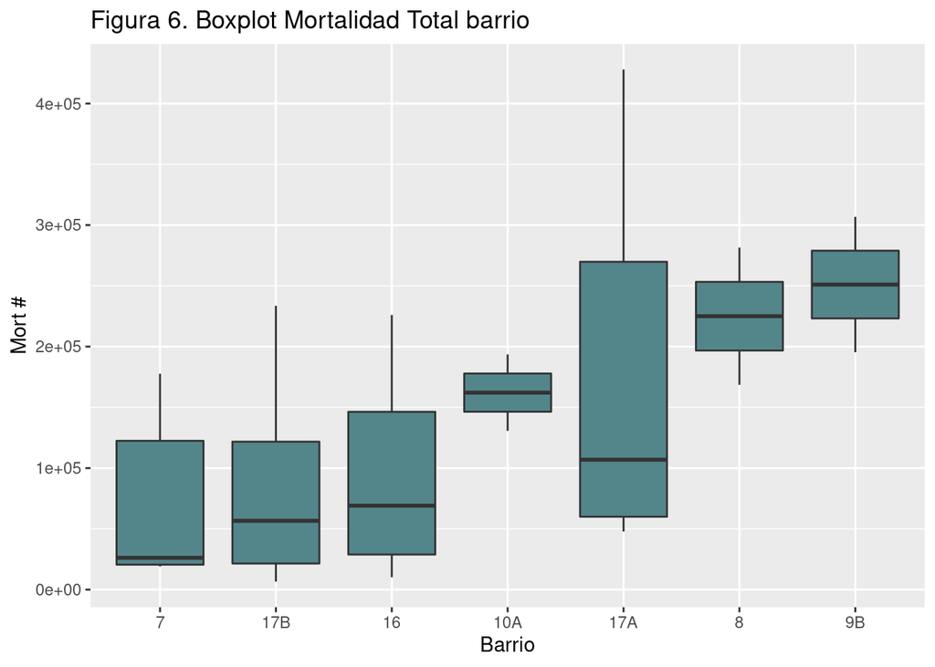

```r
blot_Mortalidad_Total <- ggplot(tidy_Mortalidad,aes(y=Mortalidad_Total,x=reorder(Barrio, Mortalidad_Total)))+
  geom_boxplot(fill="#53868B",outlier.colour = "#8B2323")+
  labs(title="Figura 6. Boxplot Mortalidad Total barrio",y="Mort #",x="Barrio")
blot_Mortalidad_Total
```

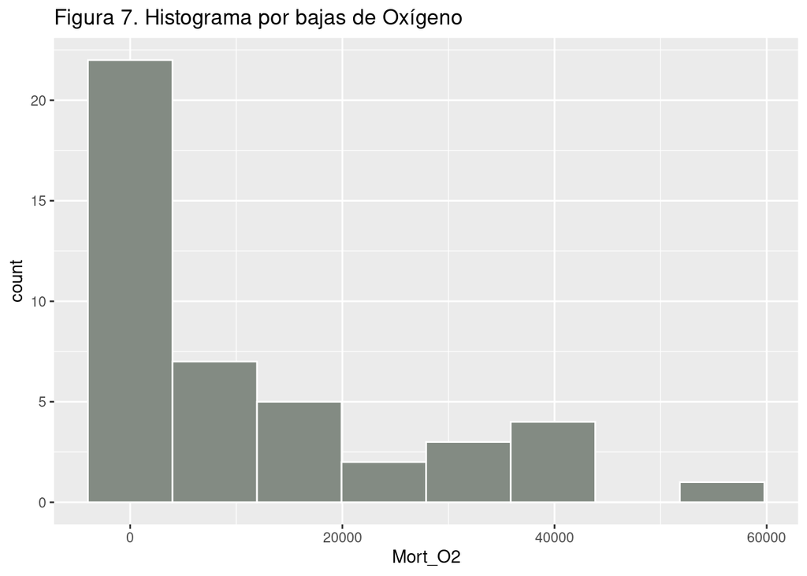

```r
hist_MortO2 <- ggplot(tidy_Mortalidad,aes(Mort_O2))+
  geom_histogram(color="White",fill="#838B83",bins=8)+
  labs(title = "Figura 7. Histograma por bajas de Oxígeno")
hist_MortO2
```

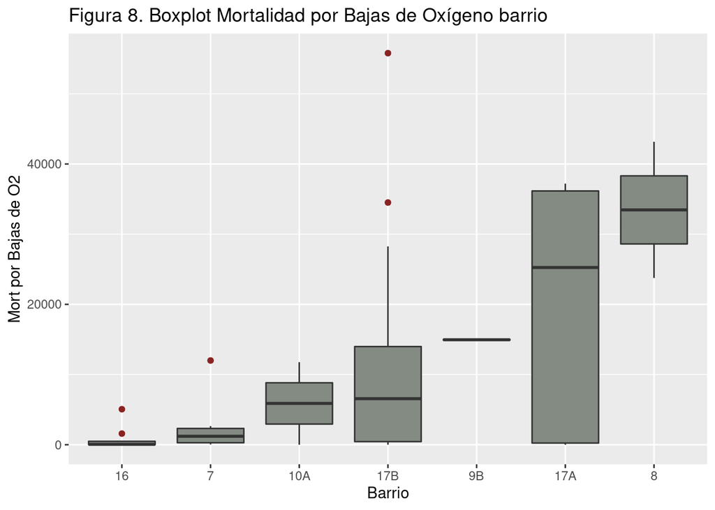

```r
blot_MortO2 <- ggplot(tidy_Mortalidad,aes(y=Mort_O2,x=reorder(Barrio, Mort_O2 )))+
  geom_boxplot(fill="#838B83",outlier.colour = "#8B2323")+
  labs(title="Figura 8. Boxplot Mortalidad por Bajas de Oxígeno barrio",y="Mort por Bajas de O2",x="Barrio")
blot_MortO2
```

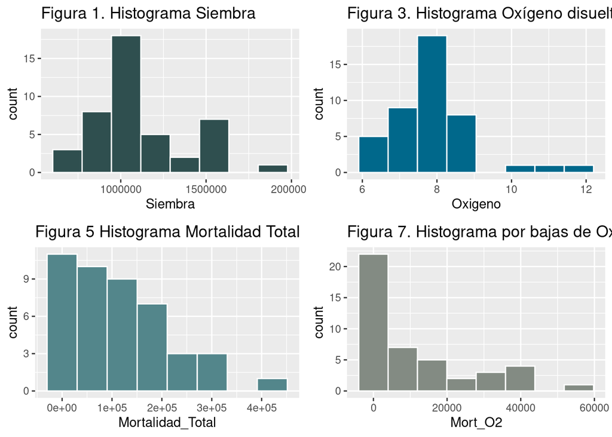

```r
grid.arrange(hist_Siembra, hist_O2, hist_Mortalidad_Total, hist_MortO2, ncol=2, nrow =2)
```

En los gráficos de boxplot se observan datos atípicos que representan números máximos o mínimos en siembra para el barrio 16, y en el caso del barrio 17A también se observa un centro que fue sembrado com más peces que el promedio o rango del barrio. Para el caso de la concentración en el grafico de boxplot se observa que en el barrio 17B y 16 esxisten valores que escapan del promedio del barrio y del promedio de todos los barrios, para las muestras del barrio 9b y 8 se observa que no hay mayor variación de los datos. Para la mortalidad total por barrio no se observan datos outlier, sin embargo si se observa variación de datos por barrio y entre barrios, finalmente al observar la mortalidad por O2 se puede observar outlier en los barrios 16, 7, 17B, donde el 17B presenta el peak de mortalidad por esta causa, y para los barrios 16 y 7 si bien presentan outlier para sus respectivos barrios, estan por debajo de los promedios de los demas barrios.

En Histogramas podemos ver las distribuciones de los datos y que se condicen con los boxplot, donde las observaciones no muestran una distribucion normal.

**Graficos de Interacción**

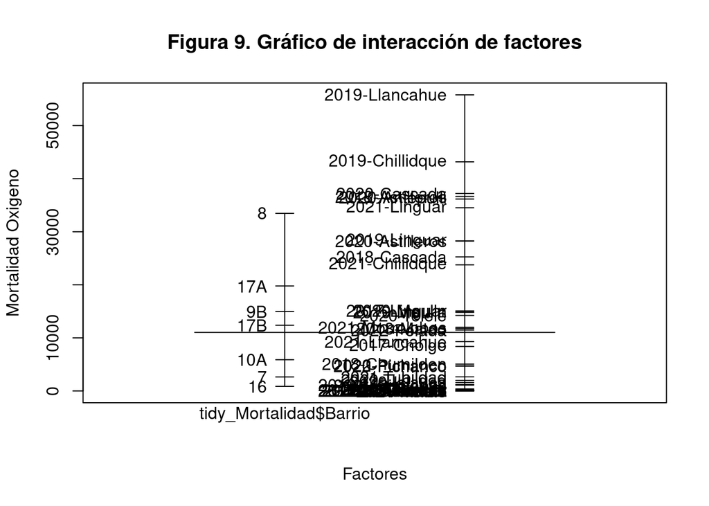

```r
plot.design(tidy_Mortalidad$Mort_O2~tidy_Mortalidad$Barrio*tidy_Mortalidad$Centro,main="Figura 9. Gráfico de interacción de factores",xlab="Factores", ylab="Mortalidad Oxigeno")
```

[figure not shown]

```r
interaction.plot(tidy_Mortalidad$Mort_O2, tidy_Mortalidad$Barrio,tidy_Mortalidad$Oxigeno,
                 main="Figura 10. Gráfico de interacción de factores",
                 xlab="Oxígeno disuelto", ylab="Mortalidad por bajas O2", trace.label = "Barrio")
```

**Correlación de Datos O2 vs Mortalidad por O2**

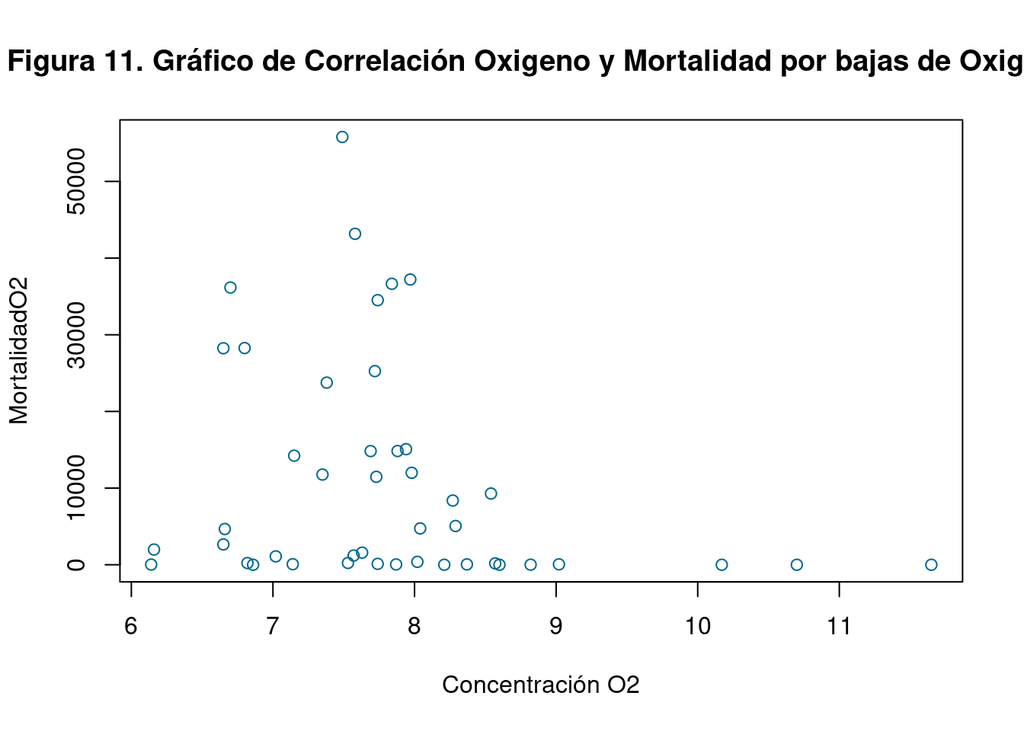

```r
plot(tidy_Mortalidad$Oxigeno, tidy_Mortalidad$Mort_O2, col="#00688B",
     main="Figura 11. Gráfico de Correlación Oxigeno y Mortalidad por bajas de Oxigeno",
     xlab="Concentración O2", ylab="MortalidadO2")
```

**Hipotesis prueba de correlación**

H0: p=0 H1: p!=0

```r
cor.test(tidy_Mortalidad$Mort_O2, tidy_Mortalidad$Oxigeno, alternative = c("two.sided") )
```

```
##
##  Pearson's product-moment correlation
##
## data:  tidy_Mortalidad$Mort_O2 and tidy_Mortalidad$Oxigeno
## t = -1.5747, df = 42, p-value = 0.1228
## alternative hypothesis: true correlation is not equal to 0
## 95 percent confidence interval:
##  -0.49807358  0.06535573
## sample estimates:
##        cor
## -0.2361058
```

Se observa que existe una correlación muy pequeña entre los datos de Oxigeno y mortalidad por bajas de oxígeno, esta correlación tan baja se debe a que el valor de oxígeno considera sólo los promedios del ciclo productivo y no todas las mediciones durante éste, por lo que es muy dificil concluir al respecto.

```r
Mortalidad_O2<-lm(Mort_O2~Barrio, data =tidy_Mortalidad)
anova(Mortalidad_O2)
```

```
## Analysis of Variance Table
##
## Response: Mort_O2
##           Df     Sum Sq   Mean Sq F value  Pr(>F)
## Barrio     6 3126189522 521031587  3.1862 0.01271 *
## Residuals 37 6050498300 163526981
## ---
## Signif. codes:  0 '***' 0.001 '**' 0.01 '*' 0.05 '.' 0.1 ' ' 1
```

```r
shapiro.test(residuals(Mortalidad_O2))
```

```
##
##  Shapiro-Wilk normality test
##
## data:  residuals(Mortalidad_O2)
## W = 0.91279, p-value = 0.002757
```

```r
pander::pander(Mortalidad_O2, caption = "ANOVA a una vía de clasificación.")
```

ANOVA a una vía de clasificación.

|  | Estimate | Std. Error | t value | Pr(>\|t\|) |
| --- | --- | --- | --- | --- |
| **(Intercept)** | 5883 | 9042 | 0.6506 | 0.5194 |
| **Barrio16** | -5024 | 10110 | -0.4969 | 0.6222 |
| **Barrio17A** | 13898 | 9997 | 1.39 | 0.1728 |
| **Barrio17B** | 6498 | 9667 | 0.6722 | 0.5056 |
| **Barrio7** | -3251 | 10253 | -0.317 | 0.753 |
| **Barrio8** | 27580 | 12788 | 2.157 | 0.03759 |
| **Barrio9B** | 9073 | 12788 | 0.7095 | 0.4824 |

Si bien el modelo muestra que el barrio tiene un efecto en la mortalidad, debido a la caracteristica de las muestras, realmente no se puede concluir al respecto, ya que al observase que los datos no están balanceados, existen Barrios que presentan una mayor cantidad de observaciones y por ende, mayor incidencia en la variable respuesta (Mortaldiad por baja de oxígeno).

Dado esto en los siguientes modelos se incluirán mas variables para mejorar la respuesta de los modelos

**Evaluación de supuestos**

Se evaluan los siguientes suspuestos:

**Independencia**

Independencia de los datos: Las observaciones fueron obtenidos desde disntintos Barrios y Centros de cultivos, por lo que existe independencia.

**Homocedasticidad** Se observa en el gráfico que las varianzas de los residuales son desiguales, por lo que no se cumple el suspuest de Homocedasticidad.

**Normalidad** la distribución de los residuales no siguen la distribución normal teórica, a pesar de que existe una porción de éstos que si se ajusta a la línea recta diagonal teórica, por lo que podemos concluir que el suspuesto de normalidad no se cumple.

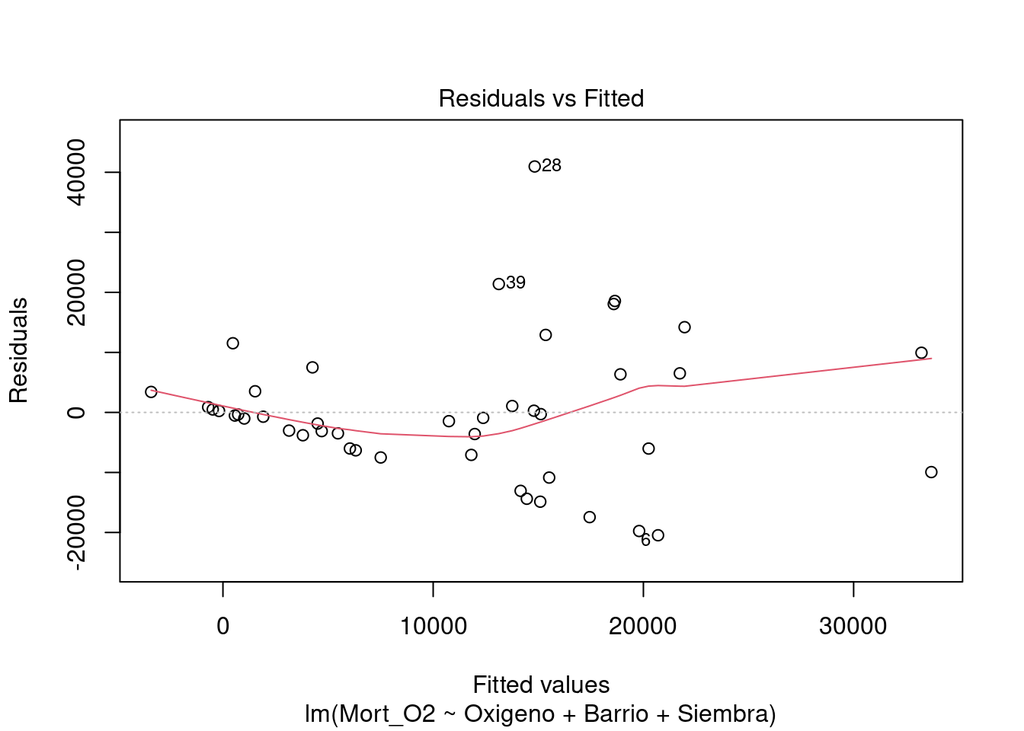

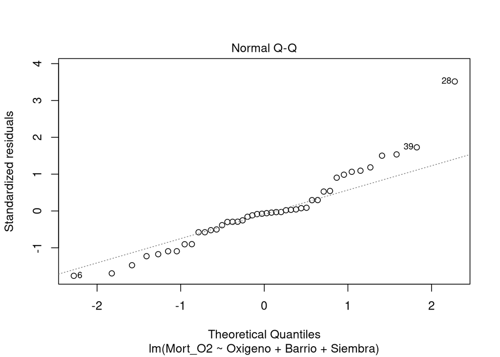

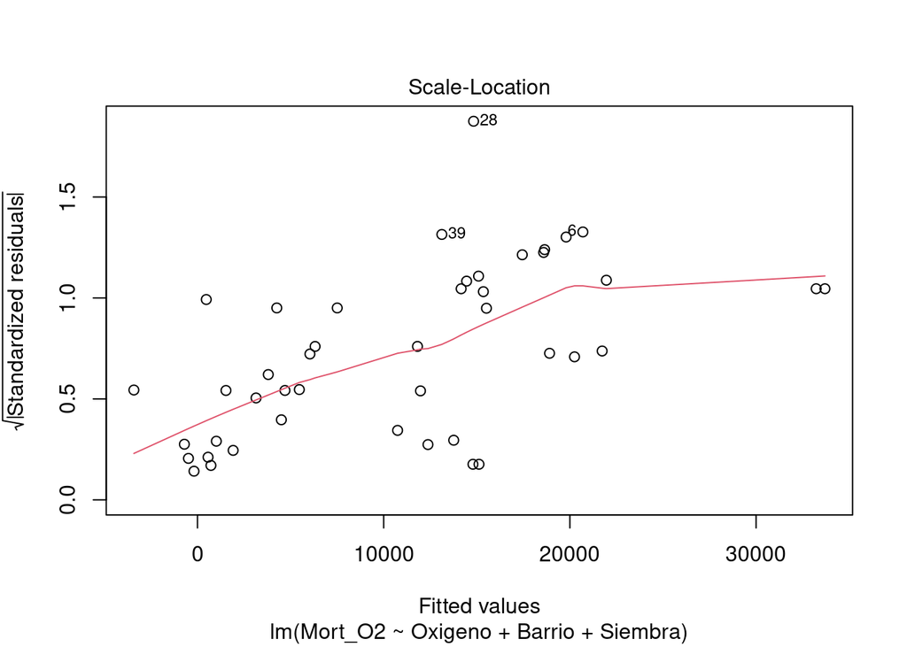

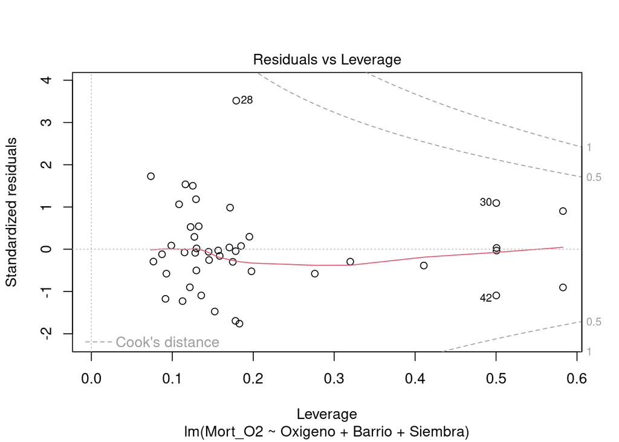

```r
Mort.O2<-lm(Mort_O2~Oxigeno + Barrio + Siembra, data=tidy_Mortalidad)
plot(Mort.O2)
```

```r
summary(Mort.O2)
```

```
##
## Call:
## lm(formula = Mort_O2 ~ Oxigeno + Barrio + Siembra, data = tidy_Mortalidad)
##
## Residuals:
##    Min     1Q Median     3Q    Max
## -20463  -6095   -811   4232  40969
##
## Coefficients:
##               Estimate Std. Error t value Pr(>|t|)
## (Intercept)  2.078e+04  1.970e+04   1.054   0.2990
## Oxigeno     -2.647e+03  2.097e+03  -1.262   0.2153
## Barrio16     1.568e+02  1.192e+04   0.013   0.9896
## Barrio17A    1.599e+04  1.081e+04   1.480   0.1479
## Barrio17B    1.000e+04  1.085e+04   0.922   0.3626
## Barrio7     -1.367e+03  1.150e+04  -0.119   0.9060
## Barrio8      2.969e+04  1.356e+04   2.189   0.0354 *
## Barrio9B     1.134e+04  1.300e+04   0.873   0.3887
## Siembra      2.572e-03  9.302e-03   0.277   0.7838
## ---
## Signif. codes:  0 '***' 0.001 '**' 0.01 '*' 0.05 '.' 0.1 ' ' 1
##
## Residual standard error: 12860 on 35 degrees of freedom
## Multiple R-squared:  0.3695, Adjusted R-squared:  0.2253
## F-statistic: 2.564 on 8 and 35 DF,  p-value: 0.02583
```

```r
anova(Mort.O2)
```

```
## Analysis of Variance Table
##
## Response: Mort_O2
##           Df     Sum Sq   Mean Sq F value  Pr(>F)
## Oxigeno    1  511562996 511562996  3.0944 0.08730 .
## Barrio     6 2866232427 477705404  2.8896 0.02149 *
## Siembra    1   12643790  12643790  0.0765 0.78375
## Residuals 35 5786248609 165321389
## ---
## Signif. codes:  0 '***' 0.001 '**' 0.01 '*' 0.05 '.' 0.1 ' ' 1
```

**Conclusión**